# Final Results and Project Report

Austin Okafor

2022-06-28

# In this phase, we will be leveraging on the results of the EDA analysis performed in the previous section in performing our analysis.

First, we install and load some packages we will need for this stage of analysis.

```r
#install.packages("tidyverse")
# install.packages("rpart.plot")
#Install and load class package
#install.packages('class')
#install.packages("caret", dependencies = c("Depends", "Suggests"))

#library(tidyverse)
library(caret)
library(class)
library(dplyr)
library(readr)
library(rpart)
library(rpart.plot)
library(tictoc)
```

Now, leveraging our previous knowledge of the data from the Descriptive Statistics analysis conducted in our last work, we will load the dataset and assign column types automatically. We will however not change any data value.

```r
# I chose not to alter the data in any way because most of the column types are factors.I felt that changing the original values may distort the true understanding of how the data is distributed, because certain levels will be lost.

# Also, due to the number of columns, it was very tedious trying to obtain the column types and ensuring no error was made during assignment. I had to redo this steps several times to ensure accuracy.

# read csv file
dataframe <-
  read_delim(
    file = "developmental_services_survey_dataset_0.csv",
    col_types = "iffffccfccfffffcfffffffffffffffffffffffffffffcccccnncccccccfcccfccccffcccccf",
    delim=",")
# Reading the first few lines of the dataset
head(dataframe)
```

```
## # A tibble: 6 x 76
##     UID SERVICES PR_Q3D PR_AGE1 PR_QF1A PR_QF1B PR_QF1C PR_QG1A PR_QG1B PR_QG1C
##   <int> <fct>    <fct>  <fct>   <fct>   <chr>   <chr>   <fct>   <chr>   <chr>
## 1     1 3        1      1       1       1       -99     1       1       -99
## 2     2 3        1      2       1       1       -99     1       1       -99
## 3     3 3        2      1       1       1       -99     1       1       -99
## 4     4 3        1      2       1       1       -99     1       1       -99
## 5     5 3        2      2       1       1       -99     1       1       -99
## 6     6 3        1      2       1       1       -99     1       1       -99
## # ... with 66 more variables: PR_QH1A <fct>, PR_QH1B <fct>, PR_QI1 <fct>,
## #   PR_QJ1 <fct>, PR_QK1 <fct>, PR_QL1 <chr>, PR_QL1A_1 <fct>, PR_QL1A_2 <fct>,
## #   PR_QL1A_3 <fct>, PR_QL1A_4 <fct>, PR_QM1A <fct>, PR_QM1B <fct>,
## #   PR_QM1C <fct>, PR_QN1_A <fct>, PR_QN1_B <fct>, PR_QN1_C <fct>,
## #   PR_QN1_D <fct>, PR_QN1_E <fct>, PR_QN1_F <fct>, PR_QN1_G <fct>,
## #   PR_QN1_H <fct>, PR_QO1_A_COMBINE <fct>, PR_QO1_B_COMBINE <fct>,
## #   PR_QO1_C_COMBINE <fct>, PR_QO1_D_COMBINE <fct>, PR_QO1_E_COMBINE <fct>, ...
## # i Use `colnames()` to see all variable names
```

# Decision Tree Classification Algorithm

Referencing the outputs of SmartEDA and DataExplorer for feature selection, I will now create a subset of the data using only the columns of high and medium importance. This will then be used for the modeling stage of our analysis in this project.

Creating Subset dataframe using columns with High and Median importance features, and adding labels for variables in services.

```r
# Create a subset of the data and substitute labels for services

subset_Data <- dataframe  %>%
  dplyr::select (c("SERVICES","PR_QL1","C_QE2_2","C_QRB1_1","C_QRB1_2","C_QS2_3","C_QRB2","C_QS1","C_QS3","C_QRB1_3","C_QS2_1","PR_AGE1","PR_QL1A_1","PR_QL1A_2","PR_QL1A_3","PR_QL1A_4","PR_QM1C","PR_QO1_C_COMBINE","PR_QQ")) %>%
  mutate(SERVICES = factor(SERVICES, levels = c(1, 2, 3), labels = c('Residential', 'Non-residential', 'Both')))


head(subset_Data)
```

```
## # A tibble: 6 x 19
##   SERVICES PR_QL1 C_QE2_2 C_QRB1_1 C_QRB1_2 C_QS2_3 C_QRB2 C_QS1 C_QS3 C_QRB1_3
##   <fct>    <chr>  <chr>   <chr>    <chr>    <chr>   <fct>  <fct> <fct> <chr>
## 1 Both     2      -99     -99      -99      -99     -99    2     -99   -99
## 2 Both     3      1       1        -99      -99     2      1     2     -99
## 3 Both     6      -99     -99      -99      -99     -99    2     -99   -99
## 4 Both     2      1       1        1        -99     1      1     2     -99
## 5 Both     2      1       1        1        -99     2      2     -99   -99
## 6 Both     2      1       -99      -99      -99     -99    2     -99   -99
## # ... with 9 more variables: C_QS2_1 <chr>, PR_AGE1 <fct>, PR_QL1A_1 <fct>,
## #   PR_QL1A_2 <fct>, PR_QL1A_3 <fct>, PR_QL1A_4 <fct>, PR_QM1C <fct>,
## #   PR_QO1_C_COMBINE <fct>, PR_QQ <fct>
## # i Use `colnames()` to see all variable names
```

```r
str(subset_Data)
```

```
## tibble [33,615 x 19] (S3: tbl_df/tbl/data.frame)
##  $ SERVICES        : Factor w/ 3 levels "Residential",..: 3 3 3 3 3 3 3 3 3 3 ...
##  $ PR_QL1          : chr [1:33615] "2" "3" "6" "2" ...
##  $ C_QE2_2         : chr [1:33615] "-99" "1" "-99" "1" ...
##  $ C_QRB1_1        : chr [1:33615] "-99" "1" "-99" "1" ...
##  $ C_QRB1_2        : chr [1:33615] "-99" "-99" "-99" "1" ...
##  $ C_QS2_3         : chr [1:33615] "-99" "-99" "-99" "-99" ...
##  $ C_QRB2          : Factor w/ 5 levels "-99","2","1",..: 1 2 1 3 2 1 3 4 1 1 ...
##  $ C_QS1           : Factor w/ 4 levels "2","1","-88",..: 1 2 1 2 1 1 1 1 3 1 ...
##  $ C_QS3           : Factor w/ 5 levels "-99","2","1",..: 1 2 1 2 1 1 1 1 1 1 ...
##  $ C_QRB1_3        : chr [1:33615] "-99" "-99" "-99" "-99" ...
##  $ C_QS2_1         : chr [1:33615] "-99" "-99" "-99" "1" ...
##  $ PR_AGE1         : Factor w/ 7 levels "1","2","3","4",..: 1 2 1 2 2 2 2 2 1 1 ...
##  $ PR_QL1A_1       : Factor w/ 3 levels "0","-99","1": 1 2 2 1 1 1 2 2 2 1 ...
##  $ PR_QL1A_2       : Factor w/ 3 levels "1","-99","0": 1 2 2 1 1 1 2 2 2 1 ...
##  $ PR_QL1A_3       : Factor w/ 3 levels "0","-99","1": 1 2 2 1 1 1 2 2 2 1 ...
##  $ PR_QL1A_4       : Factor w/ 3 levels "0","-99","1": 1 2 2 1 1 1 2 2 2 1 ...
##  $ PR_QM1C         : Factor w/ 4 levels "1","-88","2",..: 1 2 3 3 1 2 2 3 2 3 ...
##  $ PR_QO1_C_COMBINE: Factor w/ 5 levels "3","2","-88",..: 1 1 1 1 1 1 1 2 3 1 ...
##  $ PR_QQ           : Factor w/ 7 levels "-88","2","3",..: 1 2 2 2 3 3 4 5 2 3 ...
```

Prepare data for modeling by splitting the dataset into training and test sets.

```r
# create train set and test set

set.seed(525)
train_index <- sample(1:nrow(subset_Data), 0.8 * nrow(subset_Data))
subset_train <- subset_Data[train_index,]
subset_test <- subset_Data[-train_index,]

# check dimension of train and test set to confirm accuracy of split
dim(subset_train)
```

```
## [1] 26892    19
```

```r
dim(subset_test)
```

```
## [1] 6723   19
```

Since our dependent variable, services, has more than 2 possible outcomes,a Multi-class classification algorithm is required.

# Using Classification Model:

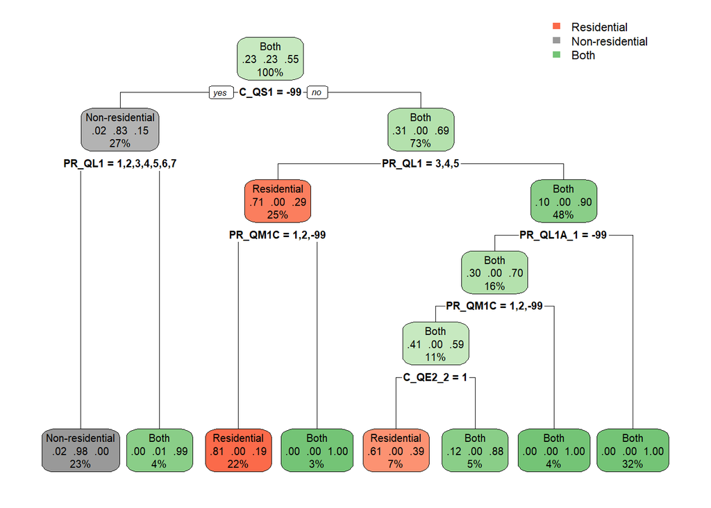

```r
fit <- rpart(SERVICES~., data = subset_train, method = 'class')
rpart.plot(fit, extra = "auto")
```

Let us test the model by making a prediction

```r
predict_services <-predict(fit, subset_test, type = 'class')

table_Dss <- table(subset_test$SERVICES, predict_services)

table_Dss
```

```
##                  predict_services
##                   Residential Non-residential Both
##   Residential            1462              38   38
##   Non-residential           0            1513    4
##   Both                    488               5 3175
```